# Forecasting And Time Series Analysis

Steve Elston

09/14/2020

# Why Are Time Series Useful?

- Data are often time-ordered
- Estimates 30% of data science problems include time series data
- Must use specific time series models

# Why Are Time Series Useful?

“It’s tough to make predictions, especially about the future!”

Yogi Berra

- **Demand forecasting:** Electricity production, Internet bandwidth, Traffic management, Inventory management, sales forecasting
- **Medicine:** Time dependent treatment effects, EKG, EEG
- **Engineering and Science:** Signal analysis, Analysis of physical processes
- **Capital markets and economics:** Seasonal unemployment, Price/return series, Risk analysis

# Why Are Time Series Data Different?

- In most machine learning we assume data samples are **independent identically distributed** (iid)
- But, this is not the case for time series data
- Time series values are correlated in time
- Exhibit **Serial correlation** `

# Why Are Time Series Data Different

Examples of series correlation:

- Temperature forecasts, where the future values are correlated with the current values
- The opening price of a stock are correlated with the price at the previous close
- The daily sales volume of a product is correlated with the previous sales volume
- A medical patient’s blood pressure reading is correlated with the previous observations

# History of Time Series Analysis

- Time series analysis have a long history
- Recognized the serial dependency in time series data early on
- Joseph Fourier and Siemon Poisson worked on time series problems in the 19th Century

[figure not shown]

Joseph Fourier

# History of Time Series Analysis

Modern history of time series analysis started with George Udny Yule (1927) and Gilbert Walker (1931)

- Yule worked on sunspot time series
- Walker was attempting to forecast the tropical monsoon cycle
- Developed the **autoregressive (AR)** model to account for series correlation
- The AR model is foundation of modern time series models

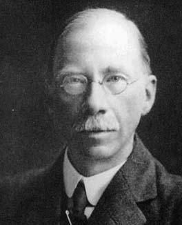

George Yule, time series pioneer

# History of Time Series Analysis

Mathematical prodigy, Norbert Weiner, invented filters for stochastic time series processes, starting in the 1920s

- Weiner’s filter theory is the basis of many time series filter methods
- Predictive filters for noisy signals; not discussed here
- Weiner process model for random walks is widely used

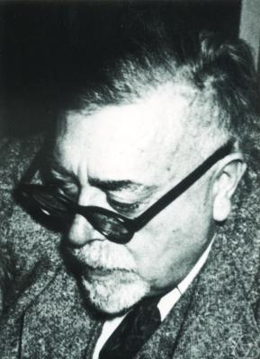

Norbert Weiner: Invented time series filters

# History of Time Series Analysis

George Box and Gwilym Jenkins fully developed a statistical theory of time series by extending the work of Yule and Walker in the 1950s and 1960s

- Extended the AR model to include **moving average (MA)** terms
- Included the **integrative term** to create the **ARIMA** model
- The ARIMA model is a main focus here

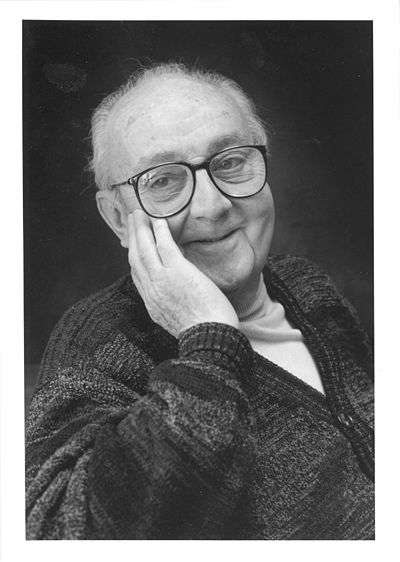

George EP Box created general time series model

[figure not shown]

Seminal time series analysis book

# History of Time Series Analysis

21st Century time series analysis

- Considerable research continues to expand the frontiers
- Bayesian time series models
  - [R bsts package](https://cran.r-project.org/web/packages/bsts/bsts.pdf) and [Python PyMC3](https://docs.pymc.io/api/distributions/timeseries.html)
- Long short term memory (LSTM) models; more next quarter
- Hidden Markov Models (HMMs) widely used
  - [Python Scikit Learn HMM](https://hmmlearn.readthedocs.io/en/stable/) or [R HMM package](https://www.rdocumentation.org/packages/HMM/versions/1.0)

# Software for Time Series Analysis

Most statistical packages have considerable time series modeling capability

- R time series analysis packages are wide and deep
  - Much leading edge research appears first in R packages
  - [CRAN Time Series Task View](https://cran.r-project.org/web/views/TimeSeries.html), maintained by Rob Hyndman, contains curated index to R time series packages
- Primary Python time series analysis package in [Statsmodels.tsa](https://www.statsmodels.org/stable/tsa.html)

# Fundamentals of Time Series

What are the fundamental properties of time series

- Representation and sampling
- White noise series
- Stationary time series
- Autocorrelation and partial autocorrelation
- Random walk series
- Trend
- Seasonal effects

# Time Series Representation

Time series are expressed as a time ordered sequence of values $(x_1, x_2, x_3, \dots, x_n)$

- We work with **discrete samples** in time order
- Sample interval $\Delta t$ is fixed
- Time measured from start of series $(0, \Delta t, 2 \Delta t, \ldots,n \Delta t)$
- Or, time measured within an **interval**
- Even continuous time processes are sampled in practice
  - Temperature
  - Pressure
  - Home price

# White Noise Series

**White noise series** are fundamental

- Values are **independent identically distributed (iid)** Normally distributed
- Can express values, $(w_1, w_2, w_3, \dots, w_n)$, of a white noise series as:

$$X(t) = (w_1, w_2, w_3, \dots, w_n)\\
where\\
w_t = N(0, \theta)$$

- No serial correlation between values
  - There is no predictive information in a white noise series
  - We want the **residuals** of time series models to be white noise series

# White Noise Series

What does a white noise series look like?

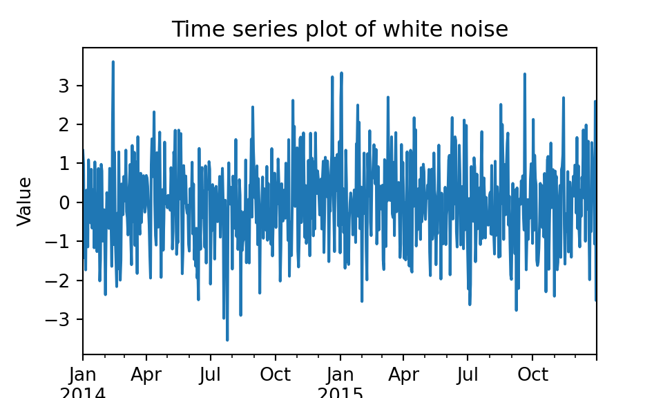

# White Noise Series

What does a white noise series look like?

- Each value is a sample is iid Normally distributed
- No trend

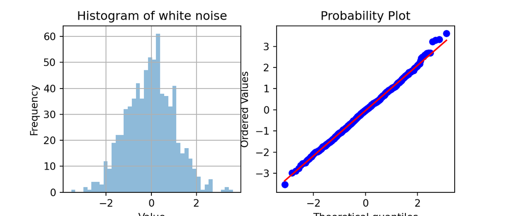

# Stationary Time Series

A white noise series is **stationary**

- A stationary time series has statistical properties constant in time
- For example, a stationary time series has **constant mean and variance** over any sample interval
- Many time series models require stationary
  - Often transform time series to make them stationary
  - More on this shortly

# Stationary Time Series

What tests can be used for stationarity?

- Plots
  - Qualitative
  - Nonstationarity from seasonality and trend are usually visible
- The [Dicky Fuller test](https://en.wikipedia.org/wiki/Dickey%E2%80%93Fuller_test)
  - Hypothesis test for stationarity
  - Null hypothesis is stationarity
  - Based on roots of AR(1) model; to be discussed shortly

# Autocorrelation Properties of White Noise Series

Can measure the correlation of a time series with itself

- The time series is correlated at different time offsets
- Each time step of offset is called a **lag**
- The **autocorrelation function (ACF)** is measured between itself and the series at each lag

# Autocorrelation Properties of White Noise Series

We compute the autocorrelation at lag $k$:

$$\rho_k = \frac{\gamma_k}{n \sigma^2} = \frac{1}{n \sigma^2} \sum_{t = 1}^N (x_{t} - \mu) \cdot (x_{t-k} - \mu)$$
Where:
$$\begin{align}
k &= lag\\
\gamma_k &= covariance\ lag\ k\\
\mu &= mean\ of\ the\ series\\
\sigma^2 &= variance\ of\ the\ series = \frac{1}{n-1}\Sigma_{t = 1}^N (x_{t} - \mu) \cdot (x_{t} - \mu)
\end{align}$$

- Notice that for any series, $\rho_0 = 1$
- In other words, the autocorrelation of any time series at **lag zero** equals 1.0
- Autocorrelation at each lag has values in the range $-1 \ge \rho \ge 1$

# Autocorrelation Properties of White Noise Series

The **partial autocorrelation** is another important property of time series

- The **partial autocorrelation function (PACF)** is the residual autocorrelation once autocorrelation is accounted for
- To compute the partial autocorrelation to lag $k$:
  - Compute the autocorrelation to lag $k$
  - Remove the linearly predictable component of the time series from the autocorrelations
  - Compute the (partial) autocorrelation of the residual to lag $k$
- The 0 lag value of the partial autocorrelation is always 1.0

# Autocorrelation Properties of White Noise Series

What are the autocorrelation and partial autocorrelation properties of a white noise series?

- The autocorrelation and partial autocorrelation are 0 for all $k \gt 0$
- Autocorrelation plot shows value at each lag selected

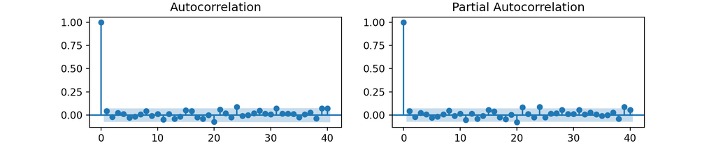

# Random Walk Time Series

$$x_t = w_t + \sum_{i=1}^{t-1} w_i$$
- $w_i$ is the ith **innovation**
- A random walk is an **integrative process**; sum or integral of innovations

*Note:* innovations are referred to by other names:  
- **Shocks** in the stochastic process literature  
- **Returns** in financial analytics

# Random Walk Time Series

What does a random walk time series look like?

- Integrating innovations leads to a ‘drift-like’ behavior
- No actual trend; random walk will eventually change apparent slope

Example with iid Normal innovations:

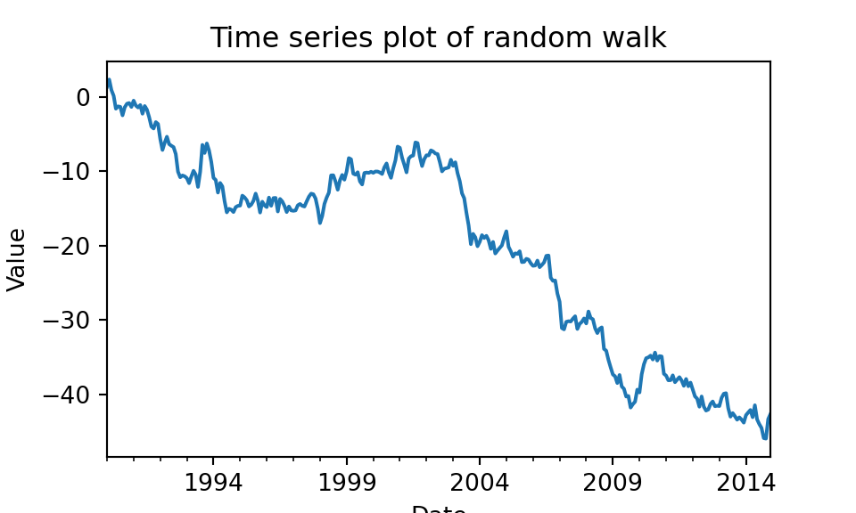

# Random Walk Time Series

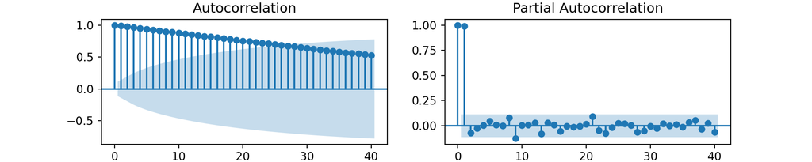

White noise series is Normally distributed

[figure not shown]

# Random Walk Time Series

Random walk time series are **non-stationary**

- Consider the **covariance** of a time series at lag $k$:

$$\gamma_k = Cov(x_t, x_{t+k})$$

- For a random walk, the increase in covariance is **unbounded in time**:
  $$\gamma_k = Cov(x_t, x_{t+k}) = t \sigma^2 \rightarrow \infty\ as\ t \rightarrow \infty$$
- Unbounded and time dependent variance make a random walk non-stationary

# Time Series With Trend

Many real-world time series have a long-term **trend**

- A trend is a long term change in the mean value of the time series
- Typically model trend as linear, polynomial, non-parametric splines, etc.
- Consider an example of a white noise series with a linear trend

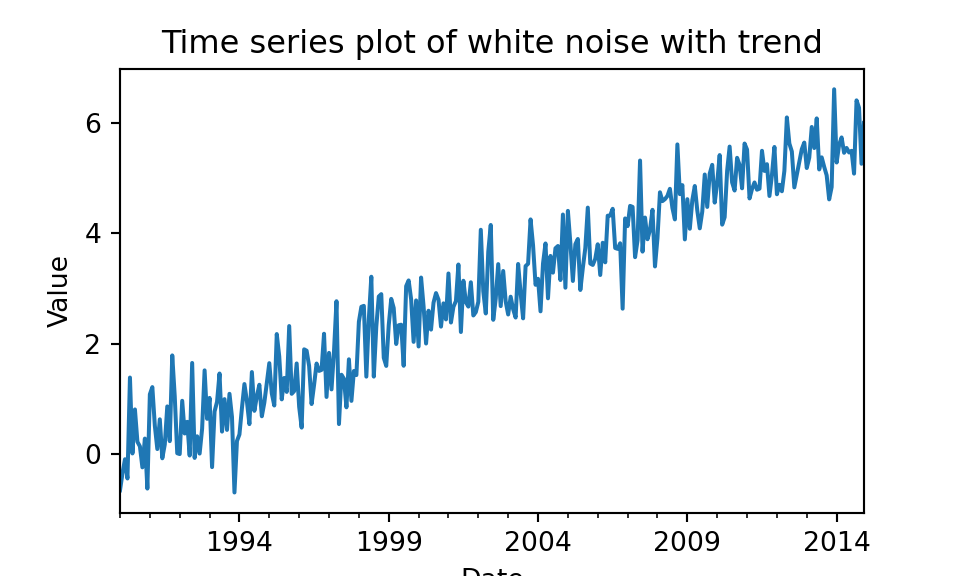

# Time Series With Trend

Time series with trend are non-stationary

- Any time series with trend is non-stationary
  - Mean and variance are dependent of window used to compute them
- The distribution of even a white noise series with trend is not-Normal

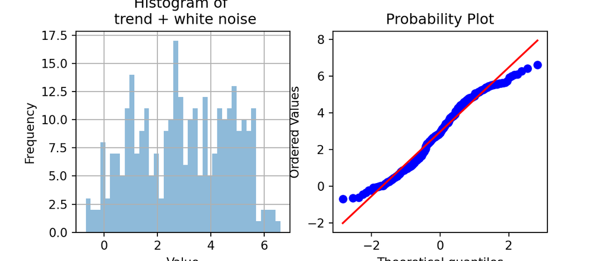

# Time Series With Trend

ACF and PACF are only properly defined for stationary series

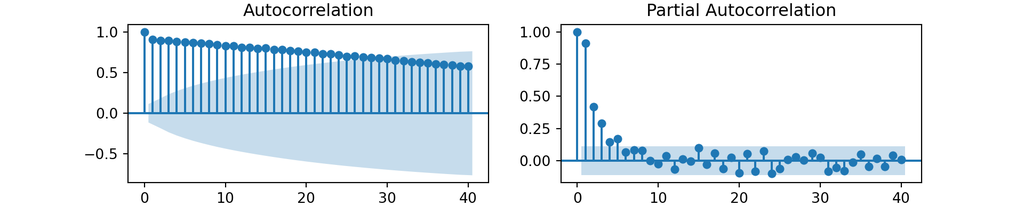

# Time Series With Seasonal Effects

Many (most?) real-world time series have **seasonal effect**

- A seasonal effect has a measurable effect that occurs periodically
- Examples of seasonal events include:
  - Day of the week
  - Last day of the month
  - Month of the year
  - Annual holiday
  - Option expiration date
  - Game day, e.g. Supper Bowl
  - $\ldots$
- Time series with seasonal effects are non-stationary
  - Mean and variance depends of sample window

# Time Series With Seasonal Effects

Example of a time series with a seasonal effect

- A white noise series with trend and seasonal behavior
- The seasonal behavior is periodic

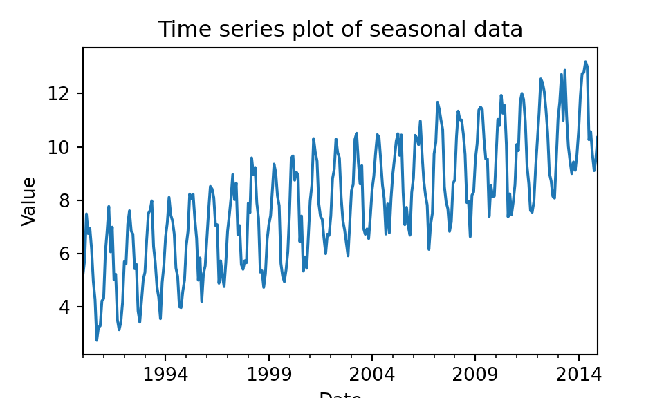

# Time Series Models

Many types of time series models; we will only consider the most widely used

- Time series decomposition
- Exponential models
- ARIMA model
  - Predictable components
  - Integrative component

# Time Series Decomposition

Two possible models for seasonal effects

- Goal, decompose the time series into its components
- The [**Seasonal Trend decomonsition model using Loess (STL)**](https://otexts.com/fpp2/stl.html) model
  - Uses a nonparametric regression model to decompose time series into components
  - Components are **seasonal (S)**, **trend (T)**, and the **residual (R)**
  - Additive decomposition model
  - Multiplicative decomposition model
- Differencing model

# Time Series Decomposition

The **additive decomposition model** is expressed as as the sum of the components:

$$TS(t) = S(t) + T(t) + R(t)$$

- Used when seasonal effect is constant in time
- Example, physical process

# Time Series Decomposition

The **Multiplicative decomposition model** is expressed as as the product of the components:

$$TS(t) = S(t) * T(t) * R(t)$$

The multiplicative form is can be hard to work with, so log transform to additive model

$$log(TS(t)) = log(S(t)) + log(T(t)) + log(R(t))$$
$$= S^l(t) + T^l(t) + R^l(t)$$

- Use when seasonal effect changes in time
- Example, economic time series

# Time Series Decomposition

Example of STL decomposition of time series with linear trend and seasonal effect

- The original series plot is on top
- Notice the estimated trend is not a straight line; a result of noise

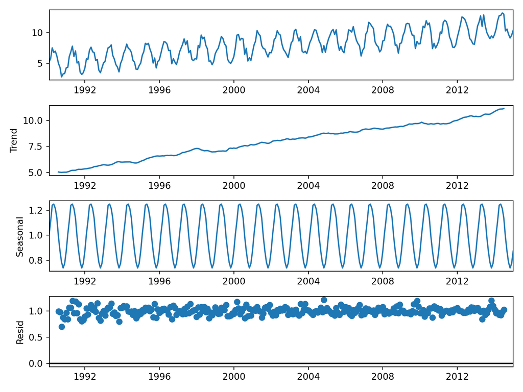

# Time Series Difference Operators

Is there an alternative for dealing with trend?

How do we deal with random walks?

- **Difference operators** are useful for both cases
- Difference operators return the innovations

$$\Delta x_t = x_t - x_{t-1}$$

- Difference operators can be of any order in principle
  - Typically use first order differences
- Difference operator of order n computes a series n shorter than original

# Time Series Difference Operators

Example of a first order difference operator applied to random walk

- The innovations look random
- Need to verify statistical properties

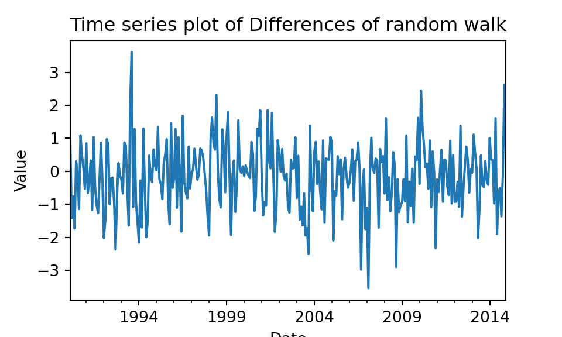

# Time Series Difference Operators

Statistical properties of the difference series

- Compute the ACF and PACF
- The plots indicate the difference series is white noise

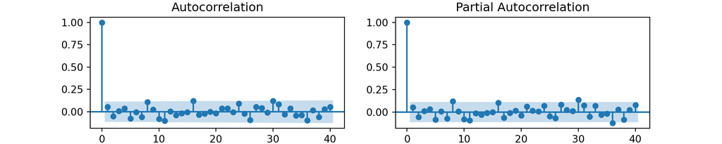

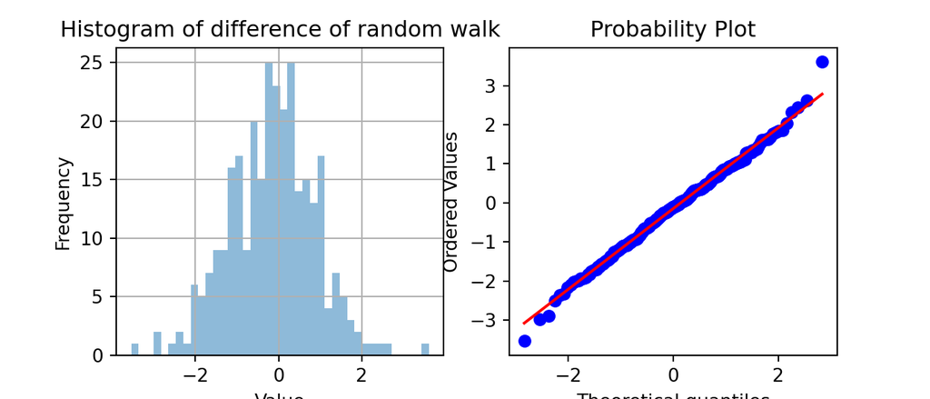

# Time Series Forecasting Models

**Forecasting** is the goal of much of time series analysis

- Exponential models; extrapolation from simple smoothers
- ARIMA and SARIMAX models; time series linear models
- For comprehensive introduction see [Forecasting: Principles and Practice, Hyndman and Athanaosopoulos, 3rd edition, 2018](https://otexts.com/fpp2/), available as book or free online
- [Rob Hyndman’s blog](https://robjhyndman.com/hyndsight/) is a source of many interesting ideas and example in time series analysis

# Exponential Smoothing Models

[Exponential smoothing models](https://en.wikipedia.org/wiki/Exponential_smoothing) are simple and widely used

- Consider the simple first order model
- Set initial conditions:

$$s_0 = x_0$$

- The smoothed update is:

$$s_t = \alpha x_t + (1-\alpha) s_{t-1}\\
= s_{t-1} \alpha(x_t - s_{t-1}),\\
t \gt 0$$

- And, the smoothing coefficient is, $0 \le \alpha \le 1$
- But, model only works if no trend

# Exponential Smoothing Models

Decay and exponential smoothing

- We can understand the smoothing parameter $\alpha$ in terms of a **decay constant**, $\tau$

$$\alpha = 1 - e^{\big( \frac{\Delta T}{\tau} \big)}$$

- An innovation or shock has an effect for all future time
- Effect decays exponentially with time, $\Delta T$

# Exponential Smoothing Models

Can extend exponential smoothing model to accommodate trend

- Algorithm known as **double exponential smoothing** or **Holt-Winters double exponential smoothing**
- Update smoothed values and slope at each time step
- Start with initial values

$$s_1 = x_1\\
b_1 = x_2 - x_1$$

- Update relationships for both smoothed value and slope

$$s_t = \alpha x_t + (1-\alpha) (s_{t-1} + b_{t-1})\\
b_t = \beta(s_t - s_{t-1}) + (1 - \beta)b_{t-1}$$

- Additional slope smoothing hyperparameter, $0 \le \beta \le 1$
- Use **third order** update includes seasonality in **Holt-Winters smoother**

# Exponential Smoothing Models

Exponential smoothing models are useful for forecasting

- Forecast dependent on the choice of smoothing parameters
- Can forecast with first, second, third order models
- For second order model (with trend) the forecast $m$ steps ahead is:

$$F_{t+m} = s_t + m b_t$$

- Third order update include seasonal terms
- Holt-Winters smoother is a **linear model!**

# Exponential Smoothing Models

Example of smoothing trend plus white noise series

- Decreasing the smoothing parameter, $\alpha$, increases smoothing
- Additionally, smooth trend
- Additional examples in [Statsmodels user documentation](https://www.statsmodels.org/stable/examples/notebooks/generated/exponential_smoothing.html)

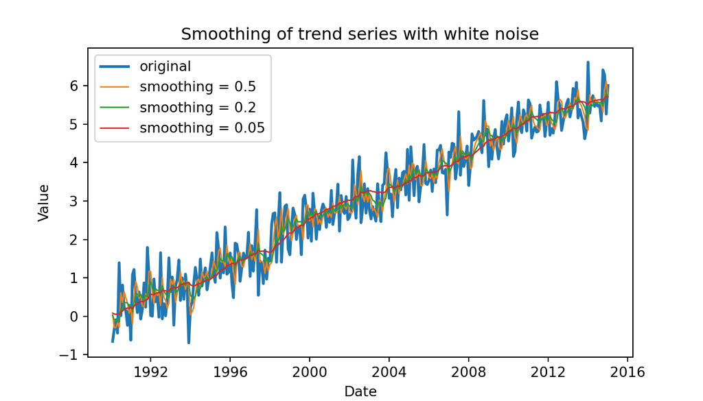

# The ARIMA and SARIMAX Model

The **ARIMA model** is composed three components:

- **Autoregressive component (AR)** accounts for partial autocorrelation
- **Integrative component (I)** accounts random walks and trend
- **Moving Average (MA)** accounts for autocorrelation
- **SARIMAX** model adds:
  - **Seasonal components (S)**
  - **Exogenous variables (X)**

# The Autoregressive Model

**Autoregressive model** relates past observed values to the current value

- An autoregressive model of order $p$, $AR(p)$, uses the last p observations:

$$x_t = \phi_1 x_{t-1} + \phi_2 x_{t-2} \dots \phi_p x_{t-p} + w \epsilon_t\\
where\\
\epsilon_t = white\ noise\ error\ at\ time\ t$$

- An AR process has the following properties:
  - $\rho_0 = 1$ always
  - $p_k = \phi^k$
  - Number of nonzero PACF values $= p$
  - A shock at any time will affect the result as $t \rightarrow \infty$
- AR model assume stationary time series

# The Autoregressive Model

How can we understand the AR model?

- Consider an AR(2) model
- The value of $y_t$ is a weighted sum $k$ previous values plus an error term

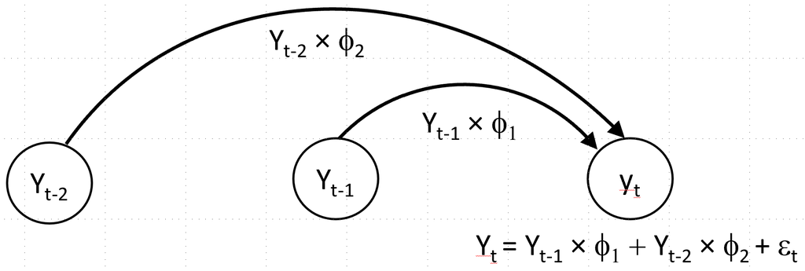

Illustration of the AR(2) model

# The Autoregressive Model

How can we understand the AR model?

- Model matrix of AR(2) model

$$A =
\begin{bmatrix}
x_1,\ 0,\ 0\\
x_2,\ x_{1},\ 0\\
x_3,\ x_{2},\ x_{1}\\
x_4,\ x_{3},\ x_{2}\\
\vdots,\ \vdots,\ \vdots\\
x_{t-2}, x_{t-3}, x_{t-4}\\
x_{t-1}, x_{t-2}, x_{t-3}\\
x_t, x_{t-1},x_{t-2}
\end{bmatrix}$$

- AR model is a **linear model!**

# The Autoregressive Model

We can rewrite the AR(1) model in terms of exceptions:

$$\mathbb{E}(X_t) = \phi_t \mathbb{E}(X_{t-1}) + \mathbb{E}(\epsilon_t) \\
or \\
\mu = c + \phi_t \mu + 0 \\
therefore \\
\mu = \frac{c}{1 - \phi_t^2 }$$

- The AR model is unstable for the roots of the polynomial $1 - \phi_t^2$
- To be a stable AR process, $\phi_t^2 \le 1$
- Violation of this condition leads to unstable model!

# The Autoregressive Model

- Time series looks a bit random
- But, notice the statistical properties; ACF, PACF
- PACF has 2 non-zero lag values, so $p=2$

```
## Is the time series stationary? True
## Is the time series invertable? True
```

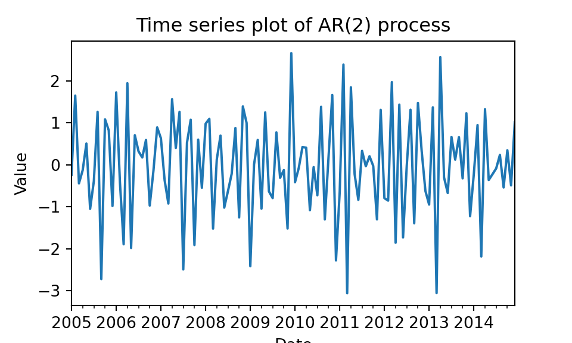

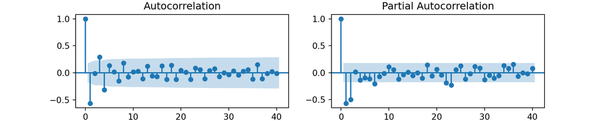

# The Autoregressive Model

Example model summary for AR(2) model:

- Both AR coefficients are statistically significant
- Notice that value of the second is wi the confidence interval

```
##                               ARMA Model Results
## ==============================================================================
## Dep. Variable:                      y   No. Observations:                  120
## Model:                     ARMA(2, 0)   Log Likelihood                -152.786
## Method:                           mle   S.D. of innovations              0.861
## Date:                Sat, 10 Apr 2021   AIC                            311.573
## Time:                        11:27:39   BIC                            319.935
## Sample:                    01-31-2005   HQIC                           314.969
##                          - 12-31-2014
## ==============================================================================
##                  coef    std err          z      P>|z|      [0.025      0.975]
## ------------------------------------------------------------------------------
## ar.L1.y       -0.8407      0.080    -10.574      0.000      -0.997      -0.685
## ar.L2.y       -0.4881      0.080     -6.136      0.000      -0.644      -0.332
##                                     Roots
## =============================================================================
##                   Real          Imaginary           Modulus         Frequency
## -----------------------------------------------------------------------------
## AR.1           -0.8613           -1.1433j            1.4314           -0.3528
## AR.2           -0.8613           +1.1433j            1.4314            0.3528
## -----------------------------------------------------------------------------
```

# The Moving Average Model

- A **moving average** model of order $q$, $MA(q)$, uses the last q error terms or shocks:

$$x_t = \mu + \epsilon_t + \theta_1 \epsilon_{t-1} + \theta_2 \epsilon_{t-2} + \cdots + \theta_q \epsilon_{t-q} \\
where\\
\epsilon_t = white\ noise\ error\ at\ time\ t$$

- An MA process has the following properties:
  - For autocorrelation, $\rho_0 = 1$ always
  - Number of $\rho_k \ne 0$, $= q$, $k \gt 0$
  - Shocks die off quickly in MA processes
- MA model assumes stationary time series

# The Moving Average Model

How can we understand the MA model?

- Model matrix of MA(2) model

$$A =
\begin{bmatrix}
x_1,\ 0,\ 0\\
x_2,\ \epsilon_{1},\ 0\\
x_3,\ \epsilon_{2},\ \epsilon_{1}\\
x_4,\ \epsilon_{3},\ \epsilon_{2}\\
\vdots,\ \vdots,\ \vdots\\
x_{t-2}, \epsilon_{t-3}, \epsilon_{t-4}\\
x_{t-1}, \epsilon_{t-2}, \epsilon_{t-3}\\
x_t, \epsilon_{t-1},\epsilon_{t-2}
\end{bmatrix}$$

- MA model is a **linear model!**

# The Moving Average Model

Example of an MA(1) model with coefficients $(1, -0.75)$

- The time series looks fairly random
- The ACF has 1 statistically significant nonzero lag value

```
## Is the time series stationary? True
## Is the time series invertable? True
```

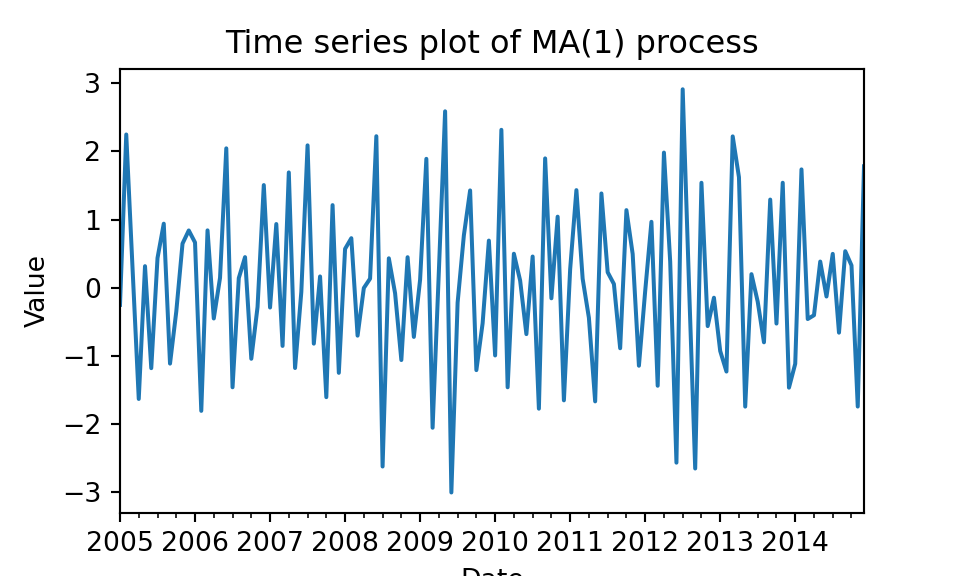

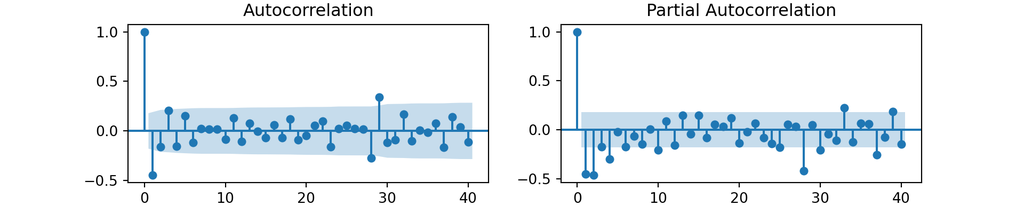

# The Moving Average Model

Example model summary for MA(1) model:

- The MA coefficient is statistically significant
- Notice that true value is within the confidence interval
- Confidence interval is wide

```
##                               ARMA Model Results
## ==============================================================================
## Dep. Variable:                      y   No. Observations:                  120
## Model:                     ARMA(0, 1)   Log Likelihood                -163.631
## Method:                           mle   S.D. of innovations              0.942
## Date:                Sat, 10 Apr 2021   AIC                            331.262
## Time:                        11:27:39   BIC                            336.837
## Sample:                    01-31-2005   HQIC                           333.526
##                          - 12-31-2014
## ==============================================================================
##                  coef    std err          z      P>|z|      [0.025      0.975]
## ------------------------------------------------------------------------------
## ma.L1.y       -0.8088      0.047    -17.150      0.000      -0.901      -0.716
##                                     Roots
## =============================================================================
##                   Real          Imaginary           Modulus         Frequency
## -----------------------------------------------------------------------------
## MA.1            1.2363           +0.0000j            1.2363            0.0000
## -----------------------------------------------------------------------------
```

# Autoregressive Moving Average Model

We can combine AR and MA terms to create the **autoregressive moving average (ARMA)** model of order $(p,q)$:

$$x_t = \epsilon_t + \phi_1 x_{t-1} + \phi_2 x_{t-2} \dots \phi_p x_{t-p} +
\theta_1 \epsilon_{t-1} + \theta_2 \epsilon_{t-2} + \cdots + \theta_q \epsilon_{t-q}$$

- ARMA model assumes stationary time series

# The ARIMA Model

The integrative model addresses certain non-stationary components of a time series

- Random walks
- Trends
- Based on difference operator
  - Typically first order difference
  - Can be higher order
  - Is deterministic, no model coefficient to estimate

# The ARIMA Model

The **autoregressive integrative moving average (ARIMA)** model includes AR, integrative and MA terms

- The order of an ARIMA is specified as (p,d,q)
  - p is the AR order
  - d is the order of differencing
  - q is the MA order
- The integrative term helps transforms trend and random walks to stationary process
- Does not account for seasonal effect

# Seasonal Models

Several possible seasonal models

- Seasonal effects can be periodic or single event (e.g. holiday, game day, etc.)
- Linear regression model to find effect for each time step in period
- STL decomposition
- SARIMAX, the S term
- Each model requires:
  - Known period of the cycle or time of seasonal event
  - Additive or logarithmic transformation

# SARIMAX Model

The SARIMAX model adds seasonal and exogenous terms

- ARIMA terms are same, (p,d,q)
- Seasonal terms:
  - ARIMA model, order (P,D,Q,S)
  - Must specify period, S
- Order of SARIMAX model is specified as (p,d,q)(P,D,Q,S)
- See [Statsmodels State Space User Guide](https://www.statsmodels.org/dev/examples/notebooks/generated/statespace_sarimax_stata.html) for more details and examples

# SARIMAX Model

The SARIMAX model (with no exogenous variables) is formulated

$$\phi_p(X) \tilde{\phi}_P(X^*) \Delta^d \Delta^D y_t = A(t) + \theta_q(X) \tilde{\theta}_Q(X^*)$$

- $\phi_p(X)$ and $\tilde{\phi}_P(X^*)$ are the AR polynomials non-seasonal and seasonal terms
- $\theta_q(X)$ and $\tilde{\theta}_Q(X^*)$ are the MA polynomials non-seasonal and seasonal terms
- $\Delta^d$ and $\Delta^D$ are the non-seasonal and seasonal differencing operators
- $A(t)$ is the trend term

# SARIMAX Model

SARIMAX model can include exogenous variables

$$y_t = \beta_t z_t + \mu_t$$
$$\phi_p(X) \tilde{\phi}_P(X^*) \Delta^d \Delta^D \mu_t = A(t) + \theta_p(X) \tilde{\theta}_P(X^*)$$

- Time series model for latent variable, $\mu_t$
- $\mu_t$ acts as the intercept term for the regression model for $y_t$
- The coefficient vector, $\beta$, contains the **effect sizes** for the exogenous variables

# Evaluating and Comparing Time Series Models

How can we evaluate time series models?

- RMSE; compare forecast to actual values
- Could use log-likelihood; $log \big(p(X|\theta) \big)$
  - $\theta = model\ parameters$
  - Use **score function** $= -2\ log(likelihood) = -2\ log \big(p(X|\theta) \big)$
- But, score will decrease with model complexity
- Need to adjust for number of model parameters
  - We always prefer simpler models; fewer parameters to learn
  - **Akaki Information Criteria (AIC)**
  - **Bayes Information Criteria (BIC)**

# Evaluating and Comparing Time Series Models

Akaki Information criteria, AIC

$$AIC = 2\ k - 2\ ln(\hat{L})\\
where\\
\hat{L} = the\ likelihood\ given\ the\ fitted\ model\ parmaters\ \hat\theta = p(x| \hat\theta)\\
x = observed\ data\\
k = number\ of\ model\ parameters$$

- AIC penalizes the score function for the complexity of the model by $2\ k$
- Model with lowest AIC is best

# Evaluating and Comparing Time Series Models

Bayes Information criteria, BIC

$$BIC = ln(n)\ k- 2\ ln(\hat{L})\\
where\\
\hat{L} = the\ likelihood\ given\ the\ fitted\ model\ parmaters\ \hat\theta = p(x| \hat\theta)\\
x = observed\ data\\
k = number\ of\ model\ parameters\\
n = number\ of\ observations$$

# Evaluating and Comparing Time Series Models

Can compare and select models using BIC or AIC

- Backwards step-wise model selection
  1. Start with initial order of the model; e.g. $(p,d,q)(P,D,Q,S)$
  2. Fit (learn) the model parameters
  3. compute the BIC, and if reduced consider this a better model
  4. Reduce the order of one of the model components
  5. Repeat steps 2, 3 and 4 until no further improvement
- Tips for comparing models:
  - BIC and AIC are approximations; small changes (3rd or 4th decimal) are not important
  - If close tie for best model pick the simpler (lower order) case
  - Often best to consider integrative terms, $d$ and $D$, separately

# SARIMAX Example

Example: 3 time series of Australian production

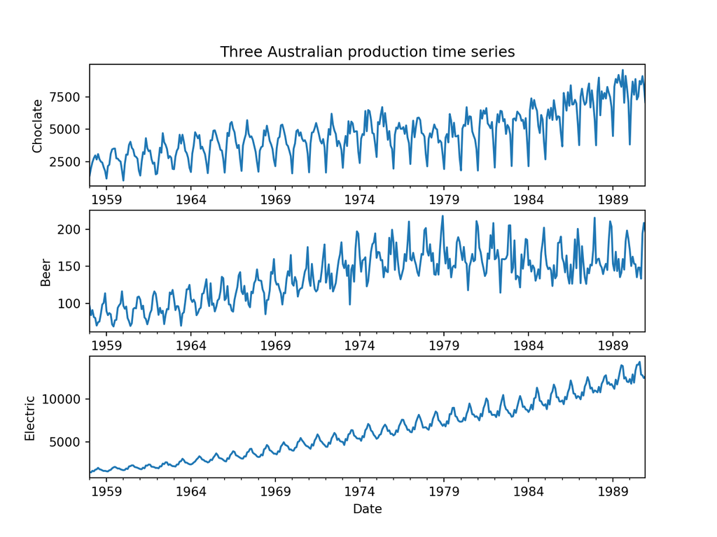

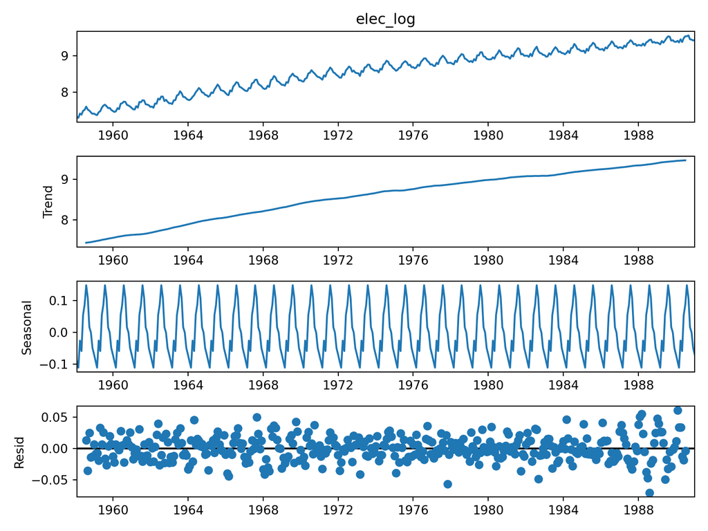

# SARIMAX Example

Use the SARIMAX model to find the best ARIMA fit of log(electric production)

```python
Log_electric = CBE.elec_log[:'1989-12-31']
best_model = pm.auto_arima(Log_electric, start_p=1, start_q=1,
                             max_p=3, max_q=3, m=12,
                             start_P=0, seasonal=True,
                             d=1, D=1, trace=True,
                             information_criterion = 'bic',
                             error_action='ignore',  # don't want to know if an order does not work
                             suppress_warnings=True,  # don't want convergence warnings
                             stepwise=True)  # set to stepwise
```

```
## Performing stepwise search to minimize bic
## Fit ARIMA: (1, 1, 1)x(0, 1, 1, 12) (constant=True); AIC=-1808.195, BIC=-1788.614, Time=2.392 seconds
## Fit ARIMA: (0, 1, 0)x(0, 1, 0, 12) (constant=True); AIC=-1573.987, BIC=-1566.154, Time=0.098 seconds
## Fit ARIMA: (1, 1, 0)x(1, 1, 0, 12) (constant=True); AIC=-1706.102, BIC=-1690.437, Time=2.255 seconds
## Fit ARIMA: (0, 1, 1)x(0, 1, 1, 12) (constant=True); AIC=-1810.577, BIC=-1794.912, Time=1.975 seconds
## Fit ARIMA: (0, 1, 0)x(0, 1, 0, 12) (constant=False); AIC=-1575.980, BIC=-1572.064, Time=0.096 seconds
## Fit ARIMA: (0, 1, 1)x(0, 1, 0, 12) (constant=True); AIC=-1704.947, BIC=-1693.198, Time=0.316 seconds
## Fit ARIMA: (0, 1, 1)x(1, 1, 1, 12) (constant=True); AIC=-1812.972, BIC=-1793.391, Time=3.175 seconds
## Fit ARIMA: (0, 1, 1)x(0, 1, 2, 12) (constant=True); AIC=-1786.851, BIC=-1767.270, Time=2.360 seconds
## Near non-invertible roots for order (0, 1, 1)(0, 1, 2, 12); setting score to inf (at least one inverse root too close to the border of the unit circle: 0.996)
## Fit ARIMA: (0, 1, 1)x(1, 1, 0, 12) (constant=True); AIC=-1752.280, BIC=-1736.615, Time=1.254 seconds
## Fit ARIMA: (0, 1, 1)x(1, 1, 2, 12) (constant=True); AIC=-1798.703, BIC=-1775.206, Time=6.279 seconds
## Near non-invertible roots for order (0, 1, 1)(1, 1, 2, 12); setting score to inf (at least one inverse root too close to the border of the unit circle: 0.991)
## Fit ARIMA: (0, 1, 0)x(0, 1, 1, 12) (constant=True); AIC=-1689.780, BIC=-1678.031, Time=2.217 seconds
## Fit ARIMA: (0, 1, 2)x(0, 1, 1, 12) (constant=True); AIC=-1808.489, BIC=-1788.908, Time=4.206 seconds
## Fit ARIMA: (1, 1, 0)x(0, 1, 1, 12) (constant=True); AIC=-1771.684, BIC=-1756.019, Time=2.140 seconds
## Fit ARIMA: (1, 1, 2)x(0, 1, 1, 12) (constant=True); AIC=-1796.422, BIC=-1772.925, Time=0.904 seconds
## Total fit time: 29.674 seconds
```

# SARIMAX Example

Example of SARIMAX model of order (0.1.1)(0,1,1,12) for monthly electric production series

- Model selected by backwards step-wise method
- First order model integrative term and MA(1)
- First order model integrative term and MA(1) for period 12 seasonality

```
## <class 'statsmodels.iolib.summary.Summary'>
## """
##                                      SARIMAX Results
## ==========================================================================================
## Dep. Variable:                                  y   No. Observations:                  384
## Model:             SARIMAX(0, 1, 1)x(0, 1, 1, 12)   Log Likelihood                 909.289
## Date:                            Sat, 10 Apr 2021   AIC                          -1810.577
## Time:                                    11:28:11   BIC                          -1794.912
## Sample:                                         0   HQIC                         -1804.356
##                                             - 384
## Covariance Type:                              opg
## ==============================================================================
##                  coef    std err          z      P>|z|      [0.025      0.975]
## ------------------------------------------------------------------------------
## intercept  -9.317e-05      0.000     -0.774      0.439      -0.000       0.000
## ma.L1         -0.6611      0.039    -16.942      0.000      -0.738      -0.585
## ma.S.L12      -0.7068      0.046    -15.364      0.000      -0.797      -0.617
## sigma2         0.0004   2.76e-05     15.379      0.000       0.000       0.000
## ===================================================================================
## Ljung-Box (Q):                       74.53   Jarque-Bera (JB):                 8.71
## Prob(Q):                              0.00   Prob(JB):                         0.01
## Heteroskedasticity (H):               0.95   Skew:                            -0.20
## Prob(H) (two-sided):                  0.79   Kurtosis:                         3.64
## ===================================================================================
##
## Warnings:
## [1] Covariance matrix calculated using the outer product of gradients (complex-step).
## """
```

# SARIMAX Example

Predictions for the last 12 months of the time series

```python
prediction = pd.Series(best_model.predict(n_periods=12),
                       index = pd.date_range(start = '1990-01-31', end = '1990-12-31', freq = 'M'))
```

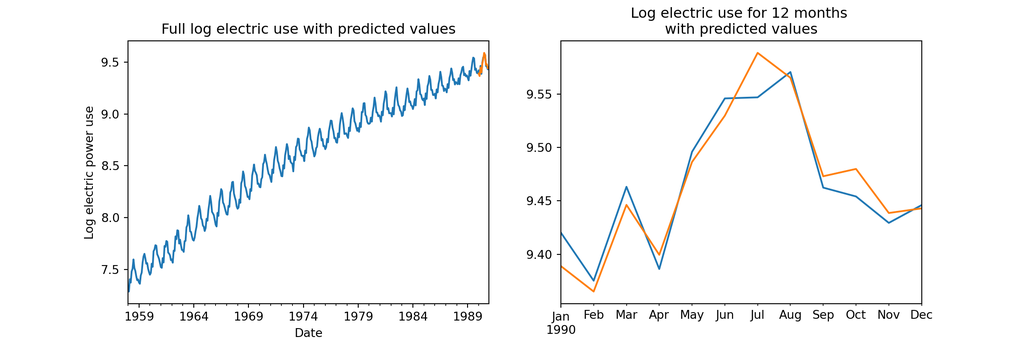

# SARIMAX Example

Residuals of the predictions

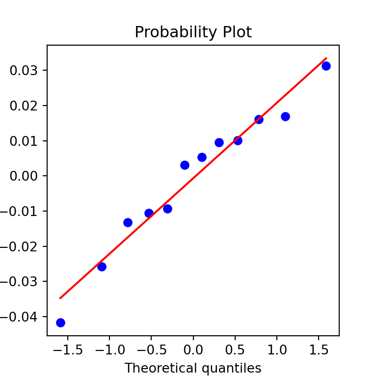

```python
residuals = CBE.elec_log['1990-01-31':] - prediction

fig, ax = plt.subplots(nrows=1, ncols=1, figsize=(4, 4))
_=ss.probplot(residuals, plot = ax);
plt.show()
```

# Summary

Fundamental elements of time series

- Fundamental components which cannot be predicted
  - White noise
  - Random walks
- Autocorrelation and partial autocorrelation
- Trend
- Seasonal components
- Stationarity properties; Dicky Fuller test

# Summary

Time series models must account for serial correlation

- Exponential models; e.g. Holt-Winters
- Second order accounts for trend
- Third order accounts for trend and seasonal

# Summary

Time series models must account for serial correlation

- e.g. ARIMA and SARIMAX
- AR components for serial correlation of values
- MA components for serial correlation of errors
- Integrative components for random walk and trend, I
- Seasonal, (P,D,Q,S)
- Exogenous variables, X

# Summary

Evaluation and model comparison

- RMSE
- AIC and BIC, penalize score function for model complexity
- Use BIC (or AIC) to perform backwards step-wise model selection